- **Title: Working example 4**
- **Output: html_document**
- **Reference: A guide to test association between Polygenic Risk Scores and psychological and psychiatric traits: practical examples**
- **Authors: Itziar Irigoien, Patricia Mas, Araceli Rosa, and Concepción Arenas**

## Working example 4

In this example we simulate 10 PRSs, and a binary trait, with gender, clinical diagnosis (with 2 categories), age, and two Principal Components as covariates.

- **data reading**

```r
dat <- read.table("WExample4.csv", header=TRUE, sep=";", dec=",")
names(dat) #
```

```
##  [1] "Sex"        "Diagnostic" "Age"        "Trait"      "PRS.1"
##  [6] "PRS.2"      "PRS.3"      "PRS.4"      "PRS.5"      "PRS.6"
## [11] "PRS.7"      "PRS.8"      "PRS.9"      "PRS.10"     "PC1"
## [16] "PC2"
```

- **do not forget to declare the categorical variables as factors**

```r
dat$Sex <- as.factor(dat$Sex)
dat$Diagnostic <- as.factor(dat$Diagnostic)
dat$Trait <- as.factor(dat$Trait)
```

- **Step 1: Order the PRSs according to the sum of the Tjur’s coefficients of discrimination. If Nagelkerke’s R^2 is prefered, set statistic=“PseudoR2” in function orderBin()**

```r
# Order the PRSs
out <- orderBin(dat, yname="Trait", prsname = "PRS.", statistic = "D")
head(out)
```

```
##          Model1    Model2    Model3    Model4       Sum
## PRS.7 0.1816453 0.1816453 0.2175212 0.2176745 0.7984862
## PRS.8 0.1657769 0.1657769 0.1921405 0.1999160 0.7236103
## PRS.1 0.1644174 0.1644174 0.1716650 0.1874602 0.6879599
## PRS.2 0.1648077 0.1648077 0.1710979 0.1799683 0.6806815
## PRS.3 0.1638651 0.1638651 0.1735185 0.1785984 0.6798472
## PRS.4 0.1581438 0.1581438 0.1715735 0.1741957 0.6620568
```

```r
mainfilename <- "WExample4"
filename <- paste0(mainfilename, "_Ordered_PRS.csv")
write.csv2(out,file=filename)
```

- **Step 1: Plot the sum of discrimination coefficients $D$. Lines: in blue the median; in black the mean**

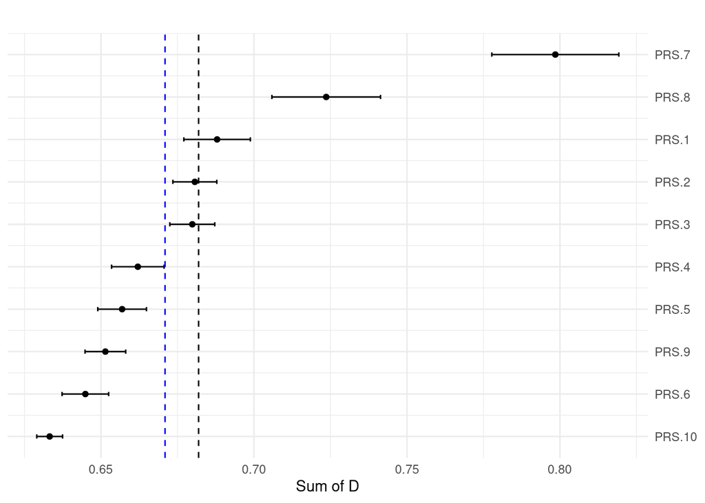

```r
out <- data.frame(out)
n <- dim(out)[1]
select <- grep("Model", names(out), value=FALSE)
out$effect <- out$Sum
sds <- apply(out[, select], 1, sd)
out$lower <- out$effect - sds
out$upper <- out$effect + sds
out$rank <- n:1


ggplot(data=out, aes(y=rank, x=effect, xmin=lower, xmax=upper)) +
  geom_point() +
  geom_errorbarh(height=.1) +
  scale_y_continuous(name=NULL, breaks= n:1, labels=row.names(out), position="right") +
  labs(title='', x='Sum of D', y = 'PRS') +
  geom_vline(xintercept=mean(out$effect), color='black', linetype='dashed') +
  geom_vline(xintercept=median(out$effect), color='blue', linetype='dashed') +
  theme_minimal()
```

### According to the obtained results, first PRS.7 is selected to analyse its association with the Trait.

- **Step 2.1: Plots to check the possible interactions**

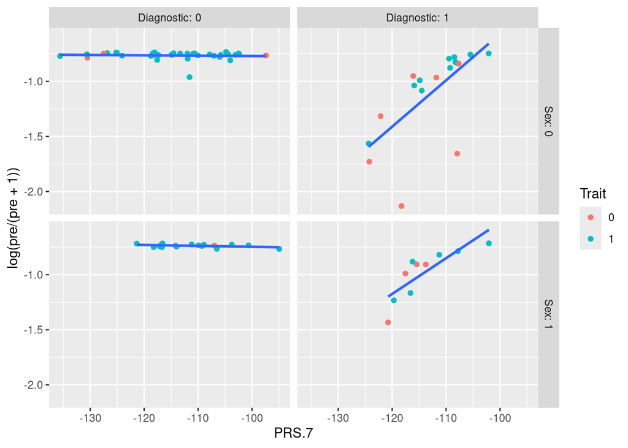

```r
# First candidate PRS.7
# Plot it
M <- glm(Trait ~ PRS.7*Sex + PRS.7*Diagnostic + Age + PC1 + PC2, data=dat, family=binomial())
pre <- M$fitted.values #predict(M,type='response')
ggplot(dat, aes(x=PRS.7, y=log(pre/(pre+1)))) +
  geom_point(aes(color=Trait)) +
  geom_smooth(method=lm, se=FALSE)+
  facet_grid(Sex ~ Diagnostic, labeller=label_both)
```

```r
# Candidate FM Trait ~ PRS + Sex + Diagnostic + PRS*Diagnostic + C1 +C2
```

### The plots suggest that the interaction between the PRS.7 and the diagnostic is relevant. Thus, we set the full model candidate (FM): $Trait \sim PRS + Sex + Diagnostic + PRS \cdot Diagnostic + Age + PC1 +PC2$

- **Step2.2: Is there evidence of overdispersion in the selected FM model?**

```r
#model
FM <- glm(Trait ~ Sex + PRS.7*Diagnostic + Age + PC1 + PC2, data=dat, family=binomial())
#Residual Deviance
FM$deviance
```

```
## [1] 67.46733
```

```r
# Ratio
FM$deviance/FM$df.residual
```

```
## [1] 0.92421
```

### Since this ratio is close to 1, there is not evidence of overdispersion

```r
#With chi-squared test
FM.od <- glm(Trait ~ Sex + PRS.7*Diagnostic + Age + PC1 + PC2, data=dat, family=quasibinomial())
pchisq(summary(FM.od)$dispersion * FM$df.residual,
       FM$df.residual, lower = F)
```

```
## [1] 0.3389642
```

### With this p-value = 0.3389 we conclude that there is not evedence of overdispersion

- **Step 3: Check the coefficients of the model**

```r
summary(FM)
```

```
##
## Call:
## glm(formula = Trait ~ Sex + PRS.7 * Diagnostic + Age + PC1 +
##     PC2, family = binomial(), data = dat)
##
## Coefficients:
##                    Estimate Std. Error z value Pr(>|z|)
## (Intercept)        1.953493   5.754567   0.339   0.7343
## Sex1               0.445672   0.698490   0.638   0.5234
## PRS.7              0.008372   0.051088   0.164   0.8698
## Diagnostic1       16.714171  11.146266   1.500   0.1337
## Age                0.043589   0.065843   0.662   0.5080
## PC1               -5.565987   4.517987  -1.232   0.2180
## PC2                3.784619   5.604881   0.675   0.4995
## PRS.7:Diagnostic1  0.162405   0.097745   1.662   0.0966 .
## ---
## Signif. codes:  0 '***' 0.001 '**' 0.01 '*' 0.05 '.' 0.1 ' ' 1
##
## (Dispersion parameter for binomial family taken to be 1)
##
##     Null deviance: 83.234  on 80  degrees of freedom
## Residual deviance: 67.467  on 73  degrees of freedom
## AIC: 83.467
##
## Number of Fisher Scoring iterations: 5
```

### The results do not indicate a clear association between PRS.7 and the Trait

- **Step 3: Check whether the respective PRS coefficients under each group are significant or not**

```r
summary(glht(FM, "PRS.7 = 0"))
```

```
##
##   Simultaneous Tests for General Linear Hypotheses
##
## Fit: glm(formula = Trait ~ Sex + PRS.7 * Diagnostic + Age + PC1 +
##     PC2, family = binomial(), data = dat)
##
## Linear Hypotheses:
##            Estimate Std. Error z value Pr(>|z|)
## PRS.7 == 0 0.008372   0.051088   0.164     0.87
## (Adjusted p values reported -- single-step method)
```

```r
summary(glht(FM, "PRS.7  + PRS.7:Diagnostic1 = 0"))
```

```
##
##   Simultaneous Tests for General Linear Hypotheses
##
## Fit: glm(formula = Trait ~ Sex + PRS.7 * Diagnostic + Age + PC1 +
##     PC2, family = binomial(), data = dat)
##
## Linear Hypotheses:
##                                Estimate Std. Error z value Pr(>|z|)
## PRS.7 + PRS.7:Diagnostic1 == 0  0.17078    0.08476   2.015   0.0439 *
## ---
## Signif. codes:  0 '***' 0.001 '**' 0.01 '*' 0.05 '.' 0.1 ' ' 1
## (Adjusted p values reported -- single-step method)
```

### That means that for those with Diagnostic=0, it seems that the PRS.7 is not related to the Trait with odds = exp(0.0082) = 1.008, but for those with Diagnosis =1 the model indicates that the coefficient of PRS.7 is 0.0082 + 0.162 = 0.1702, so the odds increase exp(0.1702) = 1.186 for an incremental of one unit in PRS.7 with a p-value=0.0439

- **Step 3: It is possible to compute a permutation test to assess whether the increase in the coefficient of determination $D$ is significative**

```r
# Null model
NM <- glm(Trait ~  Sex + Diagnostic + Age + PC1 + PC2, data=dat, family=binomial() )
permtest <- dD(NM, FM, seed=1236)
permtest
```

```
## $dD
##          1
## 0.07083991
##
## $pvalue
## [1] 0.09
```

### In this particular case, it can be seen that the coefficient of discrimination of the FM model is 0.07 units bigger than the corresponding to the *Null Model* NM, but it is not statistically significant.

- **Last step: We move to the next PRS**